# Statistical learning and deep learning: theoretical background and hands-on sessions

Lezione 3 Lab

S. Biffani

27 gennaio, 2023

# Validation Set

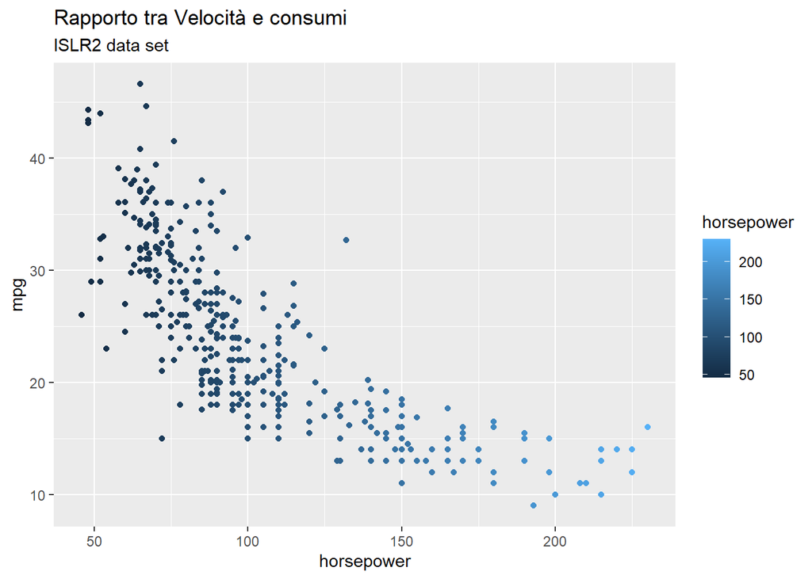

```r
###
library(ISLR2)
library(tidyverse)
set.seed(3)

Auto %>%
  ggplot(aes(horsepower,mpg,color=horsepower))+
  geom_point()+
  labs(title = 'Rapporto tra Velocità e consumi',
       subtitle = 'ISLR2 data set')
```

dividiamo in 2 il dataset: una parte di *training* ed una di *testing*

```r
set.seed(3)


train <- sample(392, 196)
```

Utilizziamo una regressione lineare con l’opzione `subset` per usare **solo** i dati di *training*

```r
set.seed(3)

###
lm.fit <- lm(mpg ~ horsepower, data = Auto, subset = train)
summary(lm.fit)
```

```
##
## Call:
## lm(formula = mpg ~ horsepower, data = Auto, subset = train)
##
## Residuals:
##      Min       1Q   Median       3Q      Max
## -13.8260  -3.5206  -0.5498   2.8799  16.6801
##
## Coefficients:
##             Estimate Std. Error t value Pr(>|t|)
## (Intercept) 40.07780    1.02775   39.00   <2e-16 ***
## horsepower  -0.15628    0.00907  -17.23   <2e-16 ***
## ---
## Signif. codes:  0 '***' 0.001 '**' 0.01 '*' 0.05 '.' 0.1 ' ' 1
##
## Residual standard error: 5.134 on 194 degrees of freedom
## Multiple R-squared:  0.6048, Adjusted R-squared:  0.6027
## F-statistic: 296.9 on 1 and 194 DF,  p-value: < 2.2e-16
```

ora calcoliamo il *test MSE*:

```r
set.seed(3)

###
attach(Auto)
mean((mpg - predict(lm.fit, Auto))[-train]^2)
```

```
## [1] 21.99239
```

ripetiamo la stessa cosa ma ora con un effetto quadratico

```r
set.seed(3)

###
lm.fit2 <- lm(mpg ~ poly(horsepower, 2), data = Auto,
    subset = train)
summary(lm.fit2)
```

```
##
## Call:
## lm(formula = mpg ~ poly(horsepower, 2), data = Auto, subset = train)
##
## Residuals:
##      Min       1Q   Median       3Q      Max
## -15.0258  -2.5714  -0.2425   2.2674  15.8950
##
## Coefficients:
##                       Estimate Std. Error t value Pr(>|t|)
## (Intercept)            23.6262     0.3255  72.576  < 2e-16 ***
## poly(horsepower, 2)1 -121.8731     6.1291 -19.884  < 2e-16 ***
## poly(horsepower, 2)2   46.3254     6.2951   7.359 5.19e-12 ***
## ---
## Signif. codes:  0 '***' 0.001 '**' 0.01 '*' 0.05 '.' 0.1 ' ' 1
##
## Residual standard error: 4.549 on 193 degrees of freedom
## Multiple R-squared:  0.6914, Adjusted R-squared:  0.6882
## F-statistic: 216.2 on 2 and 193 DF,  p-value: < 2.2e-16
```

*test MSE*:

```r
set.seed(3)

mean((mpg - predict(lm.fit2, Auto))[-train]^2)
```

```
## [1] 17.70254
```

infine usiamo un effetto **cubico**

```r
set.seed(3)

lm.fit3 <- lm(mpg ~ poly(horsepower, 3), data = Auto,
    subset = train)
summary(lm.fit3)
```

```
##
## Call:
## lm(formula = mpg ~ poly(horsepower, 3), data = Auto, subset = train)
##
## Residuals:
##      Min       1Q   Median       3Q      Max
## -15.0018  -2.4168  -0.3047   2.1842  15.7777
##
## Coefficients:
##                       Estimate Std. Error t value Pr(>|t|)
## (Intercept)            23.6205     0.3258  72.503  < 2e-16 ***
## poly(horsepower, 3)1 -121.8917     6.1326 -19.876  < 2e-16 ***
## poly(horsepower, 3)2   46.1120     6.3033   7.316 6.79e-12 ***
## poly(horsepower, 3)3   -5.5468     6.2696  -0.885    0.377
## ---
## Signif. codes:  0 '***' 0.001 '**' 0.01 '*' 0.05 '.' 0.1 ' ' 1
##
## Residual standard error: 4.551 on 192 degrees of freedom
## Multiple R-squared:  0.6926, Adjusted R-squared:  0.6878
## F-statistic: 144.2 on 3 and 192 DF,  p-value: < 2.2e-16
```

*test MSE*:

```r
set.seed(3)

mean((mpg - predict(lm.fit3, Auto))[-train]^2)
```

```
## [1] 17.71032
```

## domanda 1

come è il *train MSE*?

## domanda 2

che succede se cambio **seed** (e.g. 2) ? (cosa vuol dire?)

## domanda 3

che succede al **train** e al **test MSE** se uso un modello **molto** flessibile ? (e.g. polinomio di 10°?)

# LOOCV

Il LOOCV presuppone anch’esso la creazione di 2 set di dati (uno per il training del modello e l’altro per il testing) però la dimension dei due dataset è pari 1 (testing) e n-1 (training). La procedura si ripete n volte e quindi tutti i dati partipano sia la training che al testing. In più, rispetto al *validation set*, c’è il vantaggio di utilizzare sempre il 99% dei dati per fare training (che genera però un altro problema).

La funzione `glm`, generalmente utilizzata per modelli che analizzano Y non continue (e.g. caratteri binari) può essere utilizzata anche per modelli lineari con Y continue in combinazione con la funzione `cv.glm` della `library(boot)` che permette di eseguire cross-validation (sia LOOCV che k-fold).

I comandi `glm` o `lm` generano lo stesso risultato

```r
###
glm.fit <- glm(mpg ~ horsepower, data = Auto)
coef(glm.fit)
```

```
## (Intercept)  horsepower
##  39.9358610  -0.1578447
```

```r
###
lm.fit <- lm(mpg ~ horsepower, data = Auto)
coef(lm.fit)
```

```
## (Intercept)  horsepower
##  39.9358610  -0.1578447
```

utilizzo `cv.glm` sull’oggeto `glm.fit`

```r
library(boot)
cv.err <- cv.glm(Auto, glm.fit)
cv.err$delta
```

```
## [1] 24.23151 24.23114
```

## domanda 1

Calcolare **test MSE** con 10 modelli diversi con un crescente numero di polinomi (da 1 a 10) **hint** 1. creare vettore per immagazzinare i dati, 2. usare `for`

[output not shown]

# k-fold Cross-Validation

```r
Auto %>%
  select(-name)-> Auto
set.seed(3)
folds2=sample(rep(1:10,length=nrow(Auto)))
attach(Auto)

RESULTS<-NULL
for (k in 1:10){
  cat(paste0('Round: ',k,'\n'))
  training<-Auto[folds2!=k,] # training data set
  lm.fit <- lm(mpg ~ horsepower, data = training)
  # calcolo train MSE
  trainmse <- mean((mpg - predict(lm.fit, training))^2)
  cat(paste0('Train MSE: ',trainmse,'\n'))
  testing <- Auto[folds2==k,] # testing data set
  # calcolo test MSE
  testmse <- mean((mpg - predict(lm.fit, testing))^2)
  cat(paste0('Test MSE: ',testmse,'\n'))
  cat('\n')
  RESULTS<-bind_rows(RESULTS,data.frame(k,trainmse,testmse))
}
```

```
## Round: 1
## Train MSE: 87.1131425124453
## Test MSE: 84.5822971563068
##
## Round: 2
## Train MSE: 93.6571106447413
## Test MSE: 78.9104838010451
##
## Round: 3
## Train MSE: 83.3919180743096
## Test MSE: 97.9179518675602
##
## Round: 4
## Train MSE: 84.5542301257058
## Test MSE: 100.086507564273
##
## Round: 5
## Train MSE: 87.2264285319277
## Test MSE: 101.983799737065
##
## Round: 6
## Train MSE: 93.5369091213474
## Test MSE: 93.7791836716876
##
## Round: 7
## Train MSE: 85.279767456791
## Test MSE: 98.6569228329082
##
## Round: 8
## Train MSE: 93.3302872503926
## Test MSE: 119.683639432374
##
## Round: 9
## Train MSE: 80.0182975749597
## Test MSE: 88.744494611331
##
## Round: 10
## Train MSE: 91.2507378695747
## Test MSE: 97.9500121366966
```

## domanda 1

implementiamo almeno altri 4 modelli a crescente complessità.

### 10-fold

```
## Round: 1
## Polinomio: 1
## Train MSE: 87.1131425124453
## Test MSE: 84.5822971563068
##
## Polinomio: 3
## Train MSE: 87.624225991545
## Test MSE: 95.1026800421194
##
## Polinomio: 5
## Train MSE: 88.6395446643399
## Test MSE: 93.429646909999
##
## Polinomio: 7
## Train MSE: 87.9918313837913
## Test MSE: 93.1628657118108
##
## Round: 2
## Polinomio: 1
## Train MSE: 93.6571106447413
## Test MSE: 78.9104838010452
##
## Polinomio: 3
## Train MSE: 94.9741302116994
## Test MSE: 90.0180707375215
##
## Polinomio: 5
## Train MSE: 96.1364137994306
## Test MSE: 90.7741051126296
##
## Polinomio: 7
## Train MSE: 95.2616479625671
## Test MSE: 90.1436141035774
##
## Round: 3
## Polinomio: 1
## Train MSE: 83.3919180743097
## Test MSE: 97.9179518675602
##
## Polinomio: 3
```

[output cut: 114 more lines]

```
## Polinomio: 1
## Train MSE: 91.2507378695746
## Test MSE: 97.9500121366966
##
## Polinomio: 3
## Train MSE: 89.8723581088918
## Test MSE: 91.4119818516512
##
## Polinomio: 5
## Train MSE: 90.4540746933415
## Test MSE: 97.1176491676594
##
## Polinomio: 7
## Train MSE: 89.7989836558442
## Test MSE: 96.9751300679697
```

### 5-fold

```
## Round: 1
## Polinomio: 1
## Train MSE: 112.829606376945
## Test MSE: 89.2898832690397
##
## Polinomio: 3
## Train MSE: 112.690380280077
## Test MSE: 96.9691811005404
##
## Polinomio: 5
## Train MSE: 113.376417346429
## Test MSE: 95.3149116992577
##
## Polinomio: 7
## Train MSE: 114.356099170079
## Test MSE: 95.3449084333321
##
## Round: 2
## Polinomio: 1
## Train MSE: 117.839195467719
## Test MSE: 85.5040707675854
##
## Polinomio: 3
## Train MSE: 116.36073385979
## Test MSE: 93.1677526136939
##
## Polinomio: 5
## Train MSE: 116.986349381122
## Test MSE: 93.0595952351653
##
## Polinomio: 7
## Train MSE: 117.918400285631
## Test MSE: 94.1920333453571
##
## Round: 3
## Polinomio: 1
## Train MSE: 106.850849249085
## Test MSE: 105.307509747577
##
## Polinomio: 3
```

[output cut: 29 more lines]

```
## Polinomio: 1
## Train MSE: 109.980117440292
## Test MSE: 98.7284285748829
##
## Polinomio: 3
## Train MSE: 110.514935664225
## Test MSE: 93.8495943323125
##
## Polinomio: 5
## Train MSE: 110.672151025682
## Test MSE: 96.4622641982341
##
## Polinomio: 7
## Train MSE: 111.510696664086
## Test MSE: 97.3878631991266
```